# Stan Tutorial

June 25, 2017

## Module objective

In this module, we will build and estimate a multinomial logit model using Stan.

This will allow us to:  
- Start to learn the Stan model syntax.  
- Go through the Bayesian inference process more carefully and completely.

Think of Module 1 as the "Quick Start Guide," while Module 2 is a more comprehensive "How-To Guide".

## Stan model syntax basics

## Required Stan model components

```stan
data{
  // declarations of data go here
}
parameters{
  // declarations of parameters go here
}
model{
  // distributions for observables and
  //parameters (priors) are specified here
}
```

There are a few other types of blocks in a Stan model; the [Stan Language User's Guide and Reference Manual](https://github.com/stan-dev/stan/releases/download/v2.15.0/stan-reference-2.15.0.pdf) is a complete and relatively friendly guide.

## Stan types: scalars and arrays

Every variable in a Stan model must have a declared type. Common types are:

**Scalars** (single variable)

```stan
real myvar1;
int myvar2;
```

**Arrays**

```stan
real myarray1[2, 3]; # 2 x 3 array of reals
int myarray2[5, 6, myvar1];  # dims may be other declared variables
```

## Stan types: vectors and matrices

Specific `vector` and `matrix` types must be used when you want to do matrix operations or use multivariate probability distributions.

**Vectors and Matrices**

```stan
vector[25] myvector;  // column vector of length 25
row_vector[10] myrowvector; // row vector of length 25
matrix[10, 25] mymatrix;
```

- You can multiply a `vector` by a `matrix` or a `matrix` by a `matrix` (assuming dimenions match).
- You can not use multiplication with an `array`.
- Elements of a `vector` or `matrix` are always `real`.

## Stan types: array of vectors or matrices

You are also allowed to declare an array of vectors or an array of matricies.

**Combining matrices or vectors with arrays**

```stan
matrix[25, 3] myarrayofmatrices[1000];
```

- This produces an array of 1000 matrices that each have 25 rows and 3 columns.

## Constraints

Any declaration can include a constraint, which applies to all elements in the variable.

```stan
real<lower=0> myarray2[10, 20];
```

- For data, the constraint provides some data checking.
- For parameters, it constrains the posterior of the parameter.
- Note the model must have support (non-zero density) at every value of the parameters that meets their declared constraints. If the declared parameter constraints are less strict than the support, the samplers and optimizers may have any of a number of pathologies including just getting stuck, failure to initialize, etc.

## Summary of basic Stan types

**Scalars**

```stan
int<lower=c1, upper=c2> varname;
real<lower=c1, upper=c2> varname;
```

**Arrays**

```stan
int<lower=c1, upper=c2> varname[dim1, dim2, ...];
real<lower=c1, upper=c2> varname[dim1, dim2, ...];
```

**Vectors and Matrices**

```stan
vector<lower=c1, upper=c2>[length] varname[dim1, dim2, ...];
row_vector<lower=c1, upper=c2>[length] varname[dim1, dim2, ...];
matrix<lower=c1, upper=c2>[rows, cols] varname[dim1, dim2, ...];
```

## Stan data types: others

- While these are the main data types we use regularly, there are many other data types that Stan provides.
- We'll leave it to you to discover those in the context of specific examples where they are useful.

## Specifying probability distributions

The core of any Stan model is the `model` block, where you define probability distributions for the observables. For instance, in our linear model, we defined y as normally distributed.

```stan
y ~ normal(beta0 + X*beta, sigma);
```

This sort of declaration of the distribution of an observable is called a **sampling statement**.

## Stan probability distributions

Stan provides many, many distributions so that you can flexibly define the model.

```stan
y ~ normal(mu, sigma);
y ~ student_t(nu, mu, sigma);
y ~ cauchy(mu, sigma);
```

```stan
y ~ lognormal(mu, sigma);
y ~ exponential(beta);
```

```stan
theta ~ beta(alpha, beta);
```

```stan
n ~ poisson(lambda);
```

```stan
y ~ categorical_logit(beta);
```

## Referring to data and parameters

To pull out an element of an array or matrix you can use `[ ]`:

```stan
matrix[25, 3] myarrayofmatrices[1000];  # declared in data
...
myarrayofmatrices[1]; // first matrix in array of 1000
myarrayofmatrices[1, 2, 3]; // element in second row and third column
                            // in the first matrix in array of 1000
```

- When indexing the array of matrices, array dimensions come first, then the row and column.
  - myarrayofmatrices[1] is the first matrix in the array
  - myarrayofmatrices[1,2,3] is the element in the second row and third column

## Priors

- If you don't specify a distribution for a parameter, Stan will assume a *uniform* prior on that parameter.
  - We used uniform priors in our linear model.
- You specify a prior for a parameter by defining a distribution for the parameter in the `model` block.
- Since the NUTS algorithm used by default in Stan is gradient-based, there is no benefit to sticking to conjugate priors (as in Gibbs sampling).

## Parameters

- All parameters in a Stan model must be continuous, i.e. you can't have an `int` type parameter.
- This means you can't use models with latent discrete variables.
  - For instance you can't estimate membership variables in a mixture model.
- This is due to the fact that the MCMC algorithm that Stan uses to generate draws from the posterior relies on gradients.
- Discrete observables (like we have in the mnl) are fine!

## Learning more about Stan syntax

- The best way to learn about the Stan language is to read the [Stan Modeling Language: User’s Guide and Reference Manual](https://github.com/stan-dev/stan/releases/download/v2.16.0/stan-reference-2.16.0.pdf), which is fairly easy to read and introduces much of the syntax in the context of specific examples.
- If you want to learn about how to use Stan from R, the [rstan vignette](https://cran.r-project.org/web/packages/rstan/vignettes/rstan.html) will walk you through a typical analysis with rstan, very similar to this tutorial.
- There is a very active [Stan forum](http://discourse.mc-stan.org/) board, but since Stan does change over time, make sure the post you are looking at is recent.

## Stan code for mnl

## Stan model files

- As projects get more complicated, it is a good idea to keep the Stan code in separate file with the .stan extension.
- One advantage is that R Studio will color code the syntax in a .stan file.
- Our Stan model is in `mnl.stan`. You can check it out by opening it in RStudio or any text editor.

## Data

```stan
data {
    int<lower=2> C; // # of alternatives (choices) in each scenario
    int<lower=1> N; // # of observations
    int<lower=1> K; // # of covariates
    int<lower=1,upper=C> Y[N]; // # observed choices
    matrix[C,K] X[N]; // # matrix of attributes for each obs
}
```

## Parameters

```stan
parameters {
    vector[K] beta;
}
```

## Model

```stan
model {
  # priors
    // beta ~ normal(0,3); // often used in mcmc
    beta ~ cauchy(0, 2.5);  // better
    # model
    for (i in 1:N)
        Y[i] ~ categorical_logit(X[i]*beta);
}
```

Note that the scale of the prior on `beta` assumes that the predictors are standardized. See [Gelman (2008)](http://www.stat.columbia.edu/~gelman/research/published/standardizing7.pdf) and [Gelman(2009)](http://www.stat.columbia.edu/~gelman/research/published/priors11.pdf) for more details.

## Testing with synthetic data

## Bayesian statistical inference

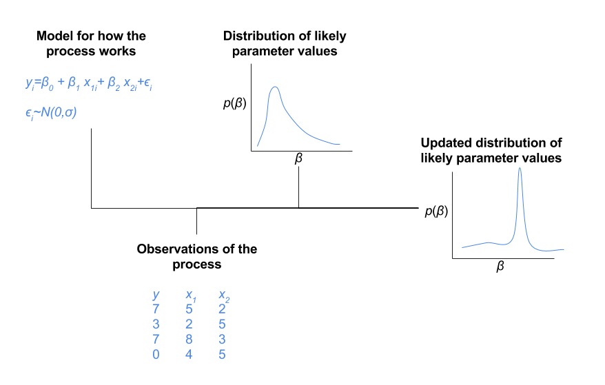

## Testing with synthetic data

- When you are building any statistical estimation routine, it is a good idea to test it out with data that you generated synthetically.
- By running the model with data where you know the parameters, you can compare to confirm that the estimation routine is is working properly.
  - In Bayesian inference, we are looking for a posterior that "covers" the true parameter values.
- This also allows you to build the analysis before you've got the data.
  - We've never been stuck waiting for data, but maybe you have ;)

## Libraries and options

Now it is time to start working in R. Open up `mnl.R` and begin by loading a few libraries and setting a few options.

```r
library(rstan)
library(shinystan)

# writes a compiled Stan program to the disk to avoid recompiling
rstan_options(auto_write=TRUE)
# allows Stan chains to run in parallel on multiprocessor machines
options(mc.cores = parallel::detectCores())
```

## Generating synthetic data

R function for generating choice data from the multinomial logit model:

```r
generate_mnl_data <- function(N=1000, C=3, beta=c(1, -2)){
  K <- length(beta)
  Y <- rep(NA, N)
  X <- list(NULL)
  for (i in 1:N) {
    X[[i]] <- matrix(rnorm(C*K), ncol=K) # normal covariates
    Y[i] <- sample(x=C, size=1, prob=exp(X[[i]]%*%beta)) # logit
  }
  list(N=N, C=C, K=K, Y=Y, X=X)
}
```

Our function returns data as a list of objects of the same names and dimensions as the declared data in `mnl.stan`. This is the format that `stan()` requires.

## Synthetic data

Use the function to generate synthetic data. Remember the true value of `beta` is 1, -2.

```r
d1 <- generate_mnl_data(N=1000, C=3, beta=c(1, -2))
str(d1)
```

```
## List of 5
##  $ N: num 1000
##  $ C: num 3
##  $ K: int 2
##  $ Y: int [1:1000] 3 1 2 3 3 2 2 3 2 2 ...
##  $ X:List of 1000
##   ..$ : num [1:3, 1:2] 1.476 1.266 -0.585 2.075 1.476 ...
##   ..$ : num [1:3, 1:2] 0.7565 -0.0714 -1.0242 -0.938 -0.6688 ...
##   ..$ : num [1:3, 1:2] 1.5626 -0.6154 -0.0138 0.3703 -0.7095 ...
##   ..$ : num [1:3, 1:2] -1.509 0.787 0.136 -0.558 0.221 ...
##   ..$ : num [1:3, 1:2] 0.122 -0.646 0.889 0.757 0.513 ...
##   ..$ : num [1:3, 1:2] -0.136 1.391 -1.122 -0.223 1.534 ...
##   ..$ : num [1:3, 1:2] -0.649 0.483 -1.399 1.219 0.185 ...
##   ..$ : num [1:3, 1:2] 0.0301 -0.7972 -0.4895 0.0758 1.4247 ...
##   ..$ : num [1:3, 1:2] 0.0539 0.5944 -1.409 -0.7943 -1.2936 ...
##   ..$ : num [1:3, 1:2] -0.312 -1.571 -0.514 0.502 -1.714 ...
##   ..$ : num [1:3, 1:2] -0.395 -0.509 -2.598 -0.149 0.887 ...
##   ..$ : num [1:3, 1:2] -0.0348 0.399 0.42 -0.0339 0.335 ...
##   ..$ : num [1:3, 1:2] 0.314 0.705 -1.116 -1.669 -0.608 ...
##   ..$ : num [1:3, 1:2] 0.51644 -0.38299 -0.25789 1.13296 -0.00628 ...
##   ..$ : num [1:3, 1:2] 1.18 2.244 -0.579 0.856 -1.164 ...
##   ..$ : num [1:3, 1:2] -1.675 -0.54 -0.143 -0.566 0.882 ...
##   ..$ : num [1:3, 1:2] -0.385 0.565 -0.341 3.475 1.703 ...
##   ..$ : num [1:3, 1:2] 1.049 -0.578 -0.434 0.41 1.898 ...
##   ..$ : num [1:3, 1:2] -0.155 -0.384 0.527 0.721 -2.145 ...
##   ..$ : num [1:3, 1:2] 0.844 0.367 1.062 1.655 -1.542 ...
##   ..$ : num [1:3, 1:2] -0.7375 0.0345 -1.0635 0.7047 1.4523 ...
##   ..$ : num [1:3, 1:2] -0.506 1.626 1.066 0.277 -0.396 ...
##   ..$ : num [1:3, 1:2] -0.312 0.482 -0.679 -0.671 -0.29 ...
##   ..$ : num [1:3, 1:2] 0.4501 1.5258 0.0951 -1.4752 1.6054 ...
##   ..$ : num [1:3, 1:2] 0.8584 1.4151 -0.2499 0.4787 0.0154 ...
##   ..$ : num [1:3, 1:2] -0.8848 0.0652 0.8595 -1.5006 -1.6786 ...
##   ..$ : num [1:3, 1:2] -1.777 0.374 0.918 -1.123 0.117 ...
##   ..$ : num [1:3, 1:2] 1.5849 0.9147 1.1072 -1.2475 -0.0971 ...
##   ..$ : num [1:3, 1:2] -0.892 1.554 0.245 -0.157 -1.404 ...
##   ..$ : num [1:3, 1:2] 0.592 0.351 0.937 -0.256 0.824 ...
##   ..$ : num [1:3, 1:2] -0.656 0.575 -1.159 0.169 0.179 ...
##   ..$ : num [1:3, 1:2] -1.1462 0.4719 -0.5269 0.0799 -0.8771 ...
##   ..$ : num [1:3, 1:2] -1.382 -0.299 -0.452 -1.486 -0.299 ...
##   ..$ : num [1:3, 1:2] 0.145 -0.149 -0.238 -2.838 -0.552 ...
```

[output cut: 51 more lines]

```
##   ..$ : num [1:3, 1:2] -1.46 -1.038 0.247 1.295 0.991 ...
##   ..$ : num [1:3, 1:2] -0.84 0.257 -0.78 -0.206 -0.289 ...
##   ..$ : num [1:3, 1:2] -0.1 0.88 0.428 0.328 -1.333 ...
##   ..$ : num [1:3, 1:2] 0.685 1.183 0.163 0.147 0.341 ...
##   ..$ : num [1:3, 1:2] 0.0566 0.0977 -0.7719 0.4936 2.4513 ...
##   ..$ : num [1:3, 1:2] 1.986 1.263 0.234 -0.117 1.074 ...
##   ..$ : num [1:3, 1:2] -2.063 2.121 1.097 -0.803 0.44 ...
##   ..$ : num [1:3, 1:2] -1.4164 0.7286 -0.0412 0.7794 0.9844 ...
##   ..$ : num [1:3, 1:2] -0.242 0.383 0.54 0.753 -1.793 ...
##   ..$ : num [1:3, 1:2] -0.688 -0.484 1.619 0.017 1.758 ...
##   ..$ : num [1:3, 1:2] 0.586 0.704 -2.669 -0.172 -0.39 ...
##   ..$ : num [1:3, 1:2] -0.902 -1.103 0.682 -0.074 -0.677 ...
##   ..$ : num [1:3, 1:2] -0.631 -0.114 1.503 0.137 -0.764 ...
##   ..$ : num [1:3, 1:2] 0.247 1.27 0.732 1.316 1.618 ...
##   .. [list output truncated]
```

## Run Stan model on synthetic data

To run the model, we call the `stan()` function. Note that we pass filename `mnl.stan` to the stan function. Make sure that file is in the working directory (or provide a full path)!

```r
test.stan <- stan(file="mnl.stan", data=d1, iter=1000, chains=4)
```

[output not shown]

[output cut: 8 more lines]

[output not shown]

```r
summary(test.stan)$summary
```

```
##                mean     se_mean         sd         2.5%          25%
## beta[1]    1.041335 0.002546267 0.07429361    0.9044762    0.9888139
## beta[2]   -2.007274 0.003727126 0.10818843   -2.2246054   -2.0807554
## lp__    -556.928851 0.037175199 1.04044186 -559.6418540 -557.3567913
##                 50%         75%       97.5%    n_eff     Rhat
## beta[1]    1.040808    1.091239    1.190926 851.3247 1.003204
## beta[2]   -2.003657   -1.934146   -1.797382 842.5846 1.005261
## lp__    -556.621284 -556.182743 -555.876639 783.3016 1.000488
```

## Running multiple chains

When we called Stan, we asked it to run the NUTS algorithm four times (independantly). This is a good practice as it allows you to assess the convergence of the algorithm! We can can access the summary for indivdual chains with the command:

```r
summary(test.stan)$c_summary
```

```
## , , chains = chain:1
##
##          stats
## parameter        mean         sd         2.5%          25%         50%
##   beta[1]    1.034599 0.07185552    0.8987929    0.9884449    1.035035
##   beta[2]   -1.994386 0.10577831   -2.2091617   -2.0618042   -1.991311
##   lp__    -556.881538 1.04369659 -559.5079884 -557.2822286 -556.606582
##          stats
## parameter         75%       97.5%
##   beta[1]    1.084107    1.175557
##   beta[2]   -1.922259   -1.781583
##   lp__    -556.173676 -555.893737
##
## , , chains = chain:2
##
##          stats
## parameter        mean        sd         2.5%          25%         50%
##   beta[1]    1.047242 0.0761273    0.9060115    0.9919768    1.043199
##   beta[2]   -2.014769 0.1059891   -2.2200981   -2.0863261   -2.010815
##   lp__    -556.953805 1.0112386 -559.5850729 -557.4385239 -556.640219
##          stats
## parameter         75%       97.5%
##   beta[1]    1.095719    1.198057
##   beta[2]   -1.940493   -1.805969
##   lp__    -556.191411 -555.877419
##
## , , chains = chain:3
##
##          stats
## parameter        mean         sd         2.5%          25%         50%
##   beta[1]    1.038211 0.07353037    0.9100884    0.9831259    1.033752
##   beta[2]   -2.006817 0.11698088   -2.2363856   -2.0830552   -2.003059
##   lp__    -556.960472 1.11962697 -559.8166915 -557.4583584 -556.553484
##          stats
## parameter         75%       97.5%
##   beta[1]    1.083578    1.193861
##   beta[2]   -1.926006   -1.780142
##   lp__    -556.176105 -555.870005
##
## , , chains = chain:4
##
##          stats
## parameter        mean         sd         2.5%          25%         50%
##   beta[1]    1.045290 0.07510099    0.9007815    0.9908118    1.049703
##   beta[2]   -2.013125 0.10259051   -2.2213149   -2.0844836   -2.009035
##   lp__    -556.919588 0.98344279 -559.5904476 -557.2650028 -556.644282
##          stats
## parameter         75%       97.5%
##   beta[1]    1.102953    1.183581
##   beta[2]   -1.946181   -1.823310
##   lp__    -556.204696 -555.873785
```

## Rhat and n_eff

- The summary reports two statistics that allow us to evaluate whether the algorithm is working properly.
  - **Rhat** compares the variation within chains to the variation between chains and should be close to 1 (also called the potential scale reduction factor)
  - **n_eff** is a crude approximation of the effective number of independent draws from the posterior

```r
summary(test.stan)$summary
```

```
##                mean     se_mean         sd         2.5%          25%
## beta[1]    1.041335 0.002546267 0.07429361    0.9044762    0.9888139
## beta[2]   -2.007274 0.003727126 0.10818843   -2.2246054   -2.0807554
## lp__    -556.928851 0.037175199 1.04044186 -559.6418540 -557.3567913
##                 50%         75%       97.5%    n_eff     Rhat
## beta[1]    1.040808    1.091239    1.190926 851.3247 1.003204
## beta[2]   -2.003657   -1.934146   -1.797382 842.5846 1.005261
## lp__    -556.621284 -556.182743 -555.876639 783.3016 1.000488
```

## Rules of thumb for Rhat and n_eff

- **Rhat** should be less than 1.1 for all parameters (and not too much less than 1)
- **n_eff** should be greater than 400 for all parameters (although we sometimes go with n_eff around 100, for long-running models)

If these conditions are not met, then  
1. Inspect the traceplots to see what is happening  
2. Run the model longer  
3. (Pro tip) Consider re-parameterizing to improve computation

## Traceplots look fine

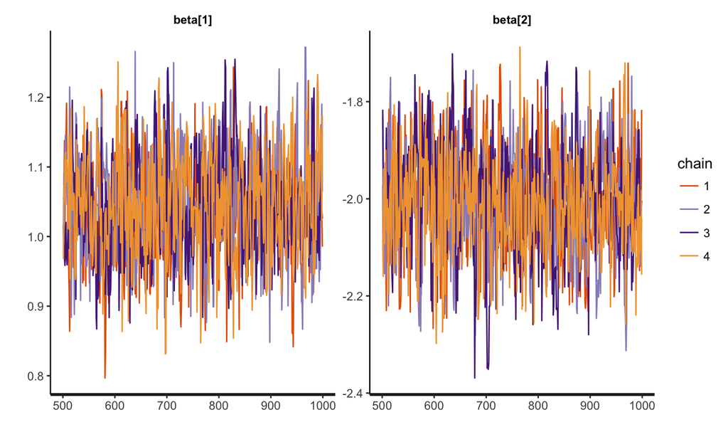

```r
plot(test.stan, plotfun="trace")
```

## Plot of the parameter estimates

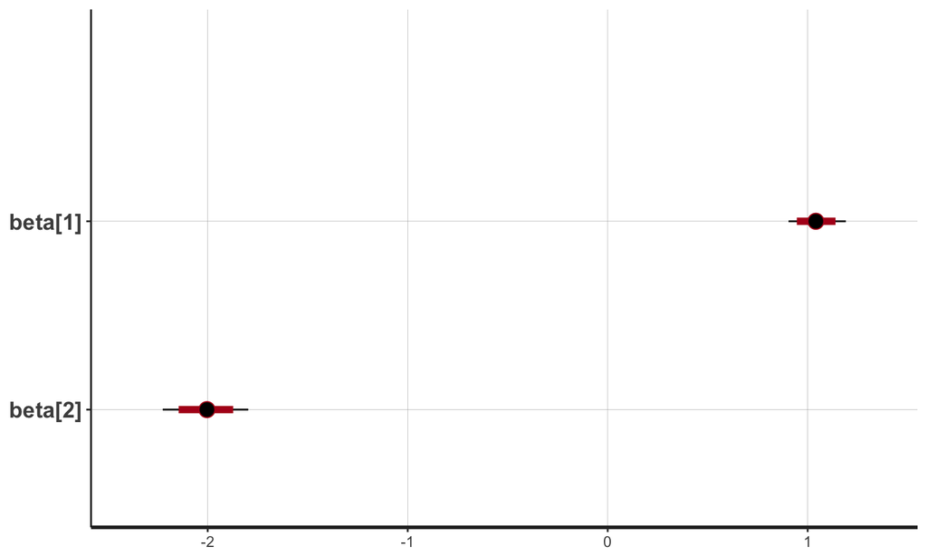

```r
plot(test.stan)
```

## Histograms of the posteriors

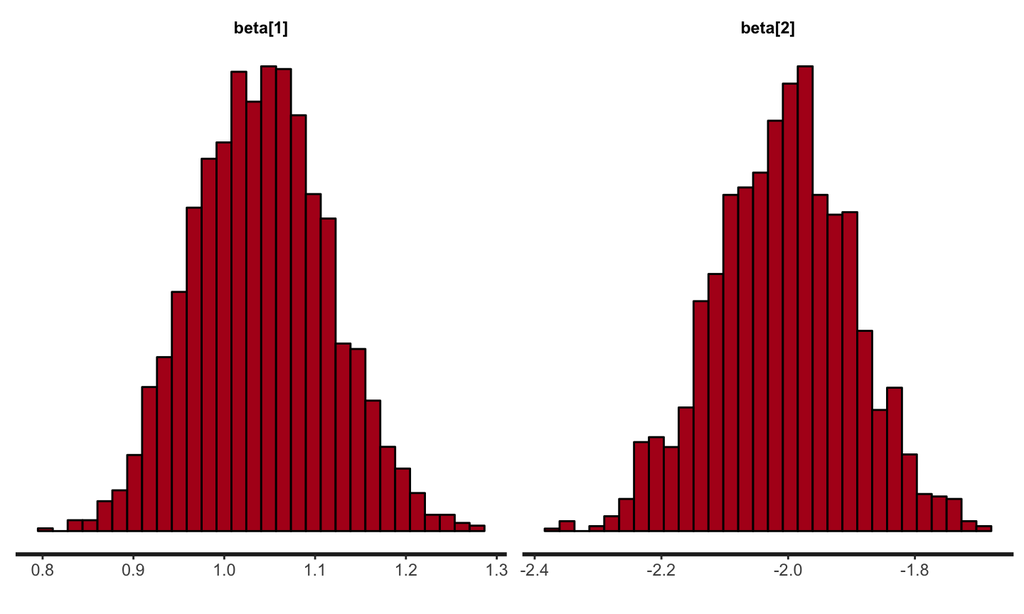

```r
plot(test.stan, plotfun="hist")
```

## Density plots of the posteriors

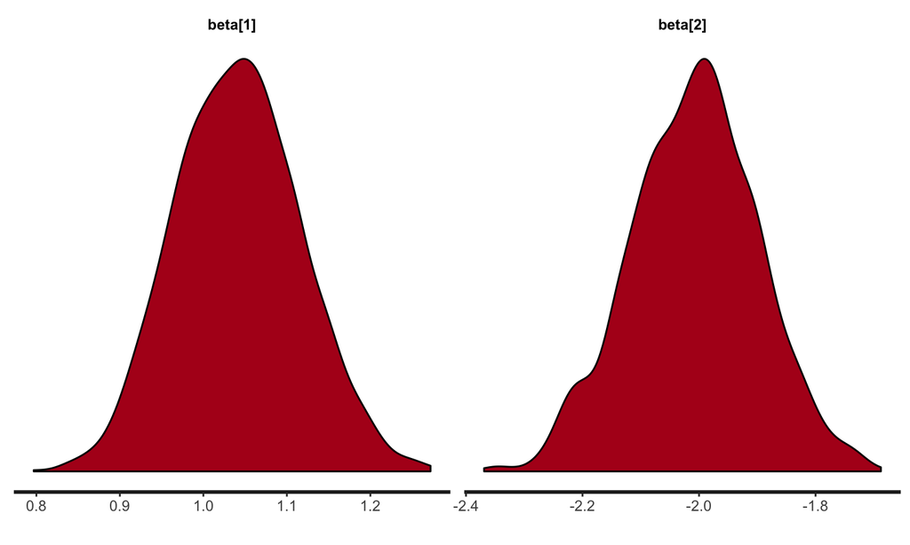

```r
plot(test.stan, plotfun="dens")
```

## Model confirmed

1. Convergence is good.
2. Estimated posteriors of `beta` include support for the true values.

This synthetic data test confirmes that Stan seems to be working well with this model. Now we can apply it to some real data.

## Choice-Based Conjoint Data for Chocolate Bars

## Choice-based conjoint data for chocolate bars

- Fourteen respondents each answered 25 choice tasks where they selected from among three chocolate bars.
- Three attributes
  - Brand: Hersheys, Dove, Lindt, Godiva, Ghirardelli
  - Type: Milk, Milk with nuts, Dark, Dark with nuts, White
- Data was generously shared by Betty Kim-Viechnicki and Joe Cable.
  - Originally described in Kim-Viechnicki, B.E., Burla, Y., Feit, E., Plassmann, H., & Kable, J.W. (2013). Decisions about chocolate are processed differently than decisions on gambles: Evidence from eye-tracking.

## Read in the chocolate data

```r
choc.df <- read.csv("cbc_chocolate.csv")
choc.df
```

```
##         X  Ind Trial Alt       Brand        Type Price Chosen
## 1       1 2401     1   1        Dove        Milk   0.6      1
## 2       2 2401     1   2      Godiva        Dark   0.7      0
## 3       3 2401     1   3        Dove       White   3.6      0
## 4       4 2401     2   1      Godiva Milk w Nuts   2.7      0
## 5       5 2401     2   2      Godiva        Dark   3.9      1
## 6       6 2401     2   3    Hersheys Milk w Nuts   0.7      0
## 7       7 2401     3   1    Hersheys Dark w Nuts   1.7      0
## 8       8 2401     3   2      Godiva        Dark   3.7      1
## 9       9 2401     3   3    Hersheys        Dark   3.0      0
## 10     10 2401     4   1       Lindt        Milk   1.0      1
## 11     11 2401     4   2       Lindt Milk w Nuts   3.6      0
## 12     12 2401     4   3 Ghirardelli Dark w Nuts   0.5      0
## 13     13 2401     5   1    Hersheys Milk w Nuts   0.8      0
## 14     14 2401     5   2      Godiva        Dark   1.5      1
```

[output cut: 1036 more lines]

## Summary of chocolate data

```r
summary(choc.df)
```

```
##        X               Ind           Trial         Alt
##  Min.   :   1.0   Min.   :2401   Min.   : 1   Min.   :1
##  1st Qu.: 263.2   1st Qu.:2405   1st Qu.: 7   1st Qu.:1
##  Median : 525.5   Median :2410   Median :13   Median :2
##  Mean   : 525.5   Mean   :2409   Mean   :13   Mean   :2
##  3rd Qu.: 787.8   3rd Qu.:2413   3rd Qu.:19   3rd Qu.:3
##  Max.   :1050.0   Max.   :2417   Max.   :25   Max.   :3
##          Brand              Type         Price           Chosen
##  Dove       :214   Dark       :233   Min.   :0.500   Min.   :0.0000
##  Ghirardelli:186   Dark w Nuts:213   1st Qu.:1.300   1st Qu.:0.0000
##  Godiva     :235   Milk       :190   Median :2.200   Median :0.0000
##  Hersheys   :207   Milk w Nuts:205   Mean   :2.211   Mean   :0.3333
##  Lindt      :208   White      :209   3rd Qu.:3.175   3rd Qu.:1.0000
##                                      Max.   :4.000   Max.   :1.0000
```

## Data inspection: **Brand** v. choice

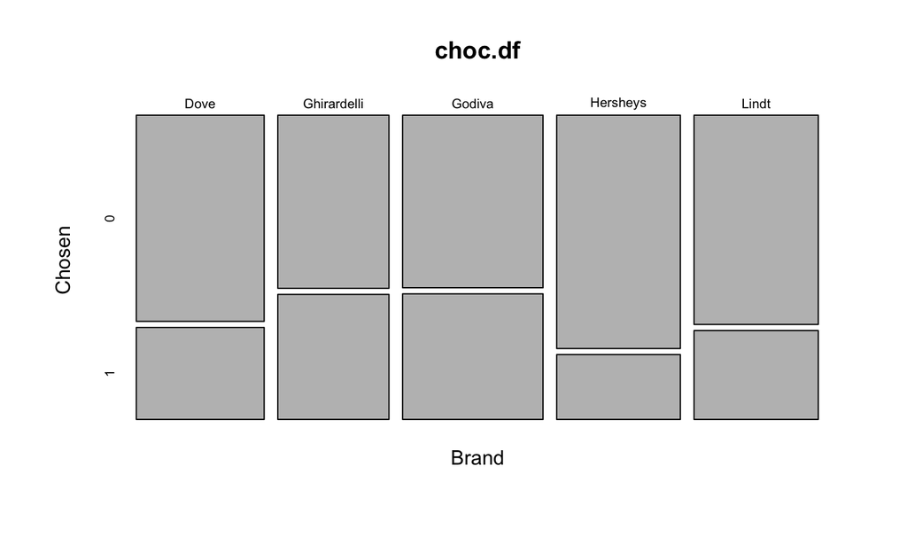

```r
mosaicplot(~ Brand + Chosen, data=choc.df)
```

## Data inspection: **Type** v. choice

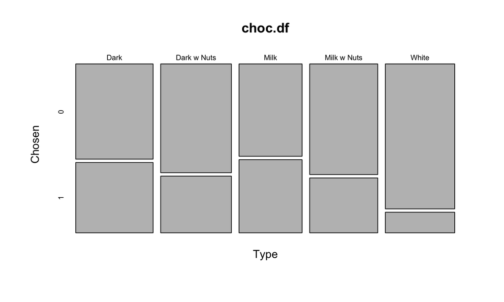

```r
mosaicplot(~ Type + Chosen, data=choc.df)
```

## Data inspection: **Price** v. choice

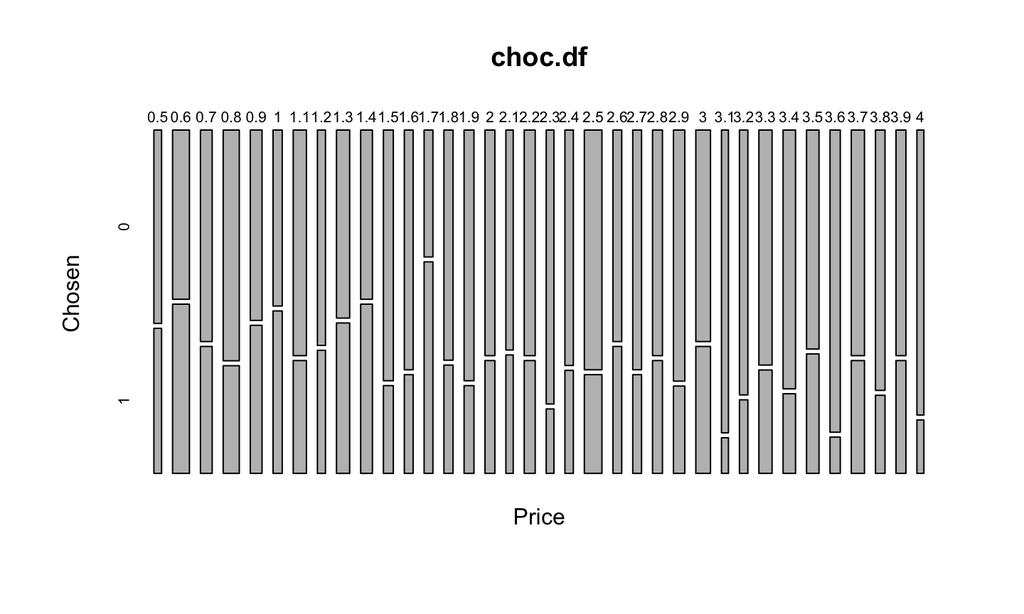

```r
mosaicplot(~ Price + Chosen, data=choc.df)
```

## Preparing the Chocolate CBC data for Stan

## Coding discrete variables

As with the computer ratings-based conjoint data in Module 1, we have two discrete attributes that need to be coded: `Brand` and `Type`.

```r
choc.df
```

```
##         X  Ind Trial Alt       Brand        Type Price Chosen
## 1       1 2401     1   1        Dove        Milk   0.6      1
## 2       2 2401     1   2      Godiva        Dark   0.7      0
## 3       3 2401     1   3        Dove       White   3.6      0
## 4       4 2401     2   1      Godiva Milk w Nuts   2.7      0
## 5       5 2401     2   2      Godiva        Dark   3.9      1
## 6       6 2401     2   3    Hersheys Milk w Nuts   0.7      0
## 7       7 2401     3   1    Hersheys Dark w Nuts   1.7      0
## 8       8 2401     3   2      Godiva        Dark   3.7      1
## 9       9 2401     3   3    Hersheys        Dark   3.0      0
## 10     10 2401     4   1       Lindt        Milk   1.0      1
## 11     11 2401     4   2       Lindt Milk w Nuts   3.6      0
## 12     12 2401     4   3 Ghirardelli Dark w Nuts   0.5      0
## 13     13 2401     5   1    Hersheys Milk w Nuts   0.8      0
## 14     14 2401     5   2      Godiva        Dark   1.5      1
```

[output cut: 1036 more lines]

## Dummy coding

As in, "Just don't do it, dummy." Unfortunately, the default coding in `model.matrix()` is dummy coding. This coding is useful in experiments where there is a control condition, but is less useful for discrete attributes in conjoint where no level is "special".

```r
model.matrix(~ Brand, data = choc.df)
```

```
##      (Intercept) BrandGhirardelli BrandGodiva BrandHersheys BrandLindt
## 1              1                0           0             0          0
## 2              1                0           1             0          0
## 3              1                0           0             0          0
## 4              1                0           1             0          0
## 5              1                0           1             0          0
## 6              1                0           0             1          0
## 7              1                0           0             1          0
## 8              1                0           1             0          0
## 9              1                0           0             1          0
## 10             1                0           0             0          1
## 11             1                0           0             0          1
## 12             1                1           0             0          0
## 13             1                0           0             1          0
## 14             1                0           1             0          0
```

[output cut: 1041 more lines]

## Effects coding (2)

```r
model.matrix(~ Brand, data = choc.df,
             contrasts = list(Brand = "contr.sum"))
```

```
##      (Intercept) Brand1 Brand2 Brand3 Brand4
## 1              1      1      0      0      0
## 2              1      0      0      1      0
## 3              1      1      0      0      0
## 4              1      0      0      1      0
## 5              1      0      0      1      0
## 6              1      0      0      0      1
## 7              1      0      0      0      1
## 8              1      0      0      1      0
## 9              1      0      0      0      1
## 10             1     -1     -1     -1     -1
## 11             1     -1     -1     -1     -1
## 12             1      0      1      0      0
## 13             1      0      0      0      1
## 14             1      0      0      1      0
```

[output cut: 1041 more lines]

## Coding the chocolate data

```r
choc.contrasts <- list(Brand = "contr.sum", Type = "contr.sum")
choc.coded <- model.matrix(~ Brand + Type, data = choc.df,
                           contrasts = choc.contrasts)
choc.coded <- choc.coded[,2:ncol(choc.coded)] # remove intercept
# Fix the bad labels from contr.sum
choc.names <- c("BrandDove", "BrandGhirardelli", "BrandGodiva",
                "BrandHersheys", "TypeDark", "TypeDarkNuts",
                "TypeMilk", "TypeMilkNuts")
colnames(choc.coded) <- choc.names
```

## Append the coded attributes to `choc.df`

```r
choc.df <- cbind(choc.df, choc.coded)
head(choc.df)
```

```
##   X  Ind Trial Alt    Brand        Type Price Chosen BrandDove
## 1 1 2401     1   1     Dove        Milk   0.6      1         1
## 2 2 2401     1   2   Godiva        Dark   0.7      0         0
## 3 3 2401     1   3     Dove       White   3.6      0         1
## 4 4 2401     2   1   Godiva Milk w Nuts   2.7      0         0
## 5 5 2401     2   2   Godiva        Dark   3.9      1         0
## 6 6 2401     2   3 Hersheys Milk w Nuts   0.7      0         0
##   BrandGhirardelli BrandGodiva BrandHersheys TypeDark TypeDarkNuts
## 1                0           0             0        0            0
## 2                0           1             0        1            0
## 3                0           0             0       -1           -1
## 4                0           1             0        0            0
## 5                0           1             0        1            0
## 6                0           0             1        0            0
##   TypeMilk TypeMilkNuts
## 1        1            0
## 2        0            0
## 3       -1           -1
## 4        0            1
## 5        0            0
## 6        0            1
```

## Respondents and questions

```r
unique(choc.df$Ind)
```

```
##  [1] 2401 2402 2403 2405 2407 2408 2409 2410 2411 2412 2413 2414 2415 2417
```

```r
unique(choc.df$Trial)
```

```
##  [1]  1  2  3  4  5  6  7  8  9 10 11 12 13 14 15 16 17 18 19 20 21 22 23
## [24] 24 25
```

## Creating objects like those declared in `mnl.stan`

```r
R <- length(unique(choc.df$Ind))
S <- length(unique(choc.df$Trial))
Y <- rep(NA, R*S)
X <- vector("list", R*S)
n <- 1
for (r in unique(choc.df$Ind)) { # respondents
  for (s in unique(choc.df$Trial)){ # choice scenarios
     scenario <- choc.df[choc.df$Ind==r & choc.df$Trial==s,]
     X[[n]] <- data.matrix(scenario[,c(7, 9:16)]) # price and coded brand and type
     Y[n] <- scenario$Alt[as.logical(scenario$Chosen)]
     n <- n + 1
  }
}
```

## Double check `X` and `Y`

```r
str(Y)
```

```
##  int [1:350] 1 2 2 1 2 3 3 3 2 2 ...
```

```r
str(X)
```

```
## List of 350
##  $ : num [1:3, 1:9] 0.6 0.7 3.6 1 0 1 0 0 0 0 ...
##   ..- attr(*, "dimnames")=List of 2
##   .. ..$ : chr [1:3] "1" "2" "3"
##   .. ..$ : chr [1:9] "Price" "BrandDove" "BrandGhirardelli" "BrandGodiva" ...
##  $ : num [1:3, 1:9] 2.7 3.9 0.7 0 0 0 0 0 0 1 ...
##   ..- attr(*, "dimnames")=List of 2
##   .. ..$ : chr [1:3] "4" "5" "6"
##   .. ..$ : chr [1:9] "Price" "BrandDove" "BrandGhirardelli" "BrandGodiva" ...
##  $ : num [1:3, 1:9] 1.7 3.7 3 0 0 0 0 0 0 0 ...
##   ..- attr(*, "dimnames")=List of 2
##   .. ..$ : chr [1:3] "7" "8" "9"
##   .. ..$ : chr [1:9] "Price" "BrandDove" "BrandGhirardelli" "BrandGodiva" ...
##  $ : num [1:3, 1:9] 1 3.6 0.5 -1 -1 0 -1 -1 1 -1 ...
##   ..- attr(*, "dimnames")=List of 2
##   .. ..$ : chr [1:3] "10" "11" "12"
##   .. ..$ : chr [1:9] "Price" "BrandDove" "BrandGhirardelli" "BrandGodiva" ...
##  $ : num [1:3, 1:9] 0.8 1.5 3.3 0 0 0 0 0 0 0 ...
##   ..- attr(*, "dimnames")=List of 2
##   .. ..$ : chr [1:3] "13" "14" "15"
##   .. ..$ : chr [1:9] "Price" "BrandDove" "BrandGhirardelli" "BrandGodiva" ...
##  $ : num [1:3, 1:9] 3.1 2.5 2.6 -1 1 0 -1 0 0 -1 ...
##   ..- attr(*, "dimnames")=List of 2
##   .. ..$ : chr [1:3] "16" "17" "18"
##   .. ..$ : chr [1:9] "Price" "BrandDove" "BrandGhirardelli" "BrandGodiva" ...
##  $ : num [1:3, 1:9] 3.1 4 2.1 0 1 0 0 0 0 1 ...
##   ..- attr(*, "dimnames")=List of 2
##   .. ..$ : chr [1:3] "19" "20" "21"
##   .. ..$ : chr [1:9] "Price" "BrandDove" "BrandGhirardelli" "BrandGodiva" ...
##  $ : num [1:3, 1:9] 0.8 3.2 1.1 0 0 0 0 0 0 0 ...
##   ..- attr(*, "dimnames")=List of 2
##   .. ..$ : chr [1:3] "22" "23" "24"
##   .. ..$ : chr [1:9] "Price" "BrandDove" "BrandGhirardelli" "BrandGodiva" ...
##  $ : num [1:3, 1:9] 2.3 1.7 3.8 -1 0 0 -1 0 0 -1 ...
##   ..- attr(*, "dimnames")=List of 2
##   .. ..$ : chr [1:3] "25" "26" "27"
##   .. ..$ : chr [1:9] "Price" "BrandDove" "BrandGhirardelli" "BrandGodiva" ...
##  $ : num [1:3, 1:9] 0.6 0.8 3.7 -1 0 0 -1 0 0 -1 ...
##   ..- attr(*, "dimnames")=List of 2
##   .. ..$ : chr [1:3] "28" "29" "30"
```

[output cut: 343 more lines]

```
##   .. ..$ : chr [1:3] "286" "287" "288"
##   .. ..$ : chr [1:9] "Price" "BrandDove" "BrandGhirardelli" "BrandGodiva" ...
##  $ : num [1:3, 1:9] 1.6 1.8 3.6 0 1 -1 0 0 -1 1 ...
##   ..- attr(*, "dimnames")=List of 2
##   .. ..$ : chr [1:3] "289" "290" "291"
##   .. ..$ : chr [1:9] "Price" "BrandDove" "BrandGhirardelli" "BrandGodiva" ...
##  $ : num [1:3, 1:9] 1.5 1.3 0.6 0 0 0 0 0 0 1 ...
##   ..- attr(*, "dimnames")=List of 2
##   .. ..$ : chr [1:3] "292" "293" "294"
##   .. ..$ : chr [1:9] "Price" "BrandDove" "BrandGhirardelli" "BrandGodiva" ...
##  $ : num [1:3, 1:9] 2.5 0.8 2.1 0 0 -1 1 1 -1 0 ...
##   ..- attr(*, "dimnames")=List of 2
##   .. ..$ : chr [1:3] "295" "296" "297"
##   .. ..$ : chr [1:9] "Price" "BrandDove" "BrandGhirardelli" "BrandGodiva" ...
##   [list output truncated]
```

## Create the list object for `stan()`

```r
choc.standata <- list(N=length(Y), C=3, K=9, Y=Y, X=X)
rm(Y, X, n, R, S, r, s, choc.contrasts, scenario, choc.coded)
```

## Estimating the mnl model using the chocolate data

## Call Stan

```r
choc.stan <- stan(file="mnl.stan", data=choc.standata)
# default: chains=4, iter=2000
```

## Check for convergence (1)

Inspect `Rhat` and `n_eff` in the summary output.

```r
summary(choc.stan)$summary[,c("n_eff", "Rhat")]
```

```
##            n_eff      Rhat
## beta[1] 4000.000 0.9996794
## beta[2] 4000.000 0.9995332
## beta[3] 4000.000 0.9998139
## beta[4] 4000.000 1.0002581
## beta[5] 4000.000 0.9994365
## beta[6] 4000.000 0.9997451
## beta[7] 4000.000 0.9992790
## beta[8] 4000.000 1.0001818
## beta[9] 4000.000 0.9999386
## lp__    1592.957 1.0009636
```

## Check for convergence (2)

Eyeball the traceplots.

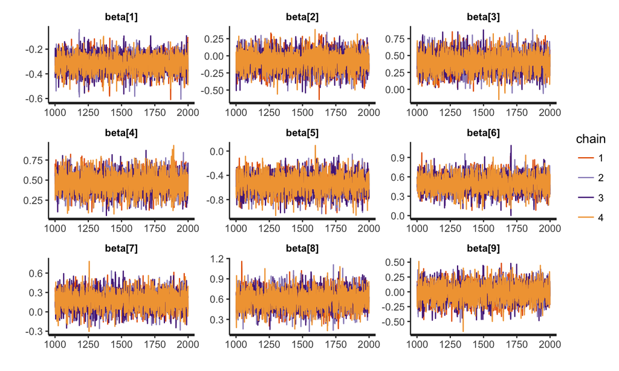

```r
plot(choc.stan, plotfun="trace")
```

## Visualize parameter posteriors

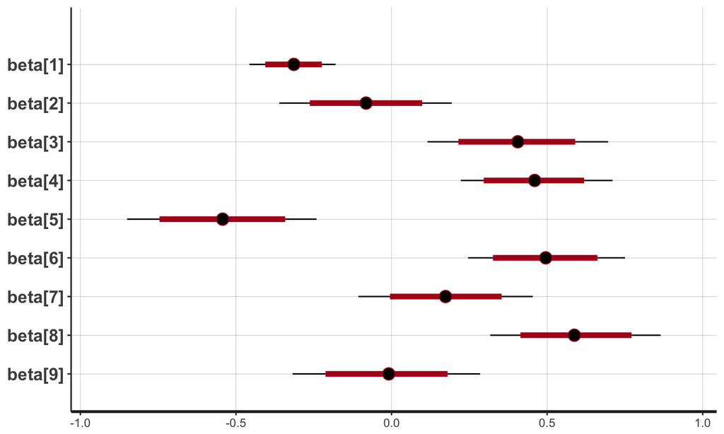

```r
plot(choc.stan)
```

## Summarize the estimates

```r
data.frame(params=c("Price", choc.names), check.names=FALSE,
           summary(choc.stan, pars=c("beta"))$summary)
```

```
##                   params        mean     se_mean         sd       2.5%
## beta[1]            Price -0.31433151 0.001143779 0.07233894 -0.4570357
## beta[2]        BrandDove -0.08335508 0.002248909 0.14223350 -0.3607629
## beta[3] BrandGhirardelli  0.40454140 0.002306114 0.14585144  0.1156286
## beta[4]      BrandGodiva  0.45937060 0.001995520 0.12620775  0.2225408
## beta[5]    BrandHersheys -0.54291065 0.002466835 0.15601632 -0.8499034
## beta[6]         TypeDark  0.49525385 0.002081247 0.13162960  0.2461364
## beta[7]     TypeDarkNuts  0.17415063 0.002222929 0.14059040 -0.1067573
## beta[8]         TypeMilk  0.58916820 0.002217490 0.14024637  0.3172985
## beta[9]     TypeMilkNuts -0.01226111 0.002423181 0.15325541 -0.3183260
##                 25%          50%         75%      97.5% n_eff      Rhat
## beta[1] -0.36190105 -0.314062969 -0.26336640 -0.1799064  4000 0.9996794
## beta[2] -0.18078775 -0.081950763  0.01473935  0.1933658  4000 0.9995332
## beta[3]  0.30521799  0.405661172  0.50267147  0.6956871  4000 0.9998139
## beta[4]  0.37087217  0.459972445  0.54596193  0.7101510  4000 1.0002581
## beta[5] -0.64546249 -0.542877214 -0.43704837 -0.2407513  4000 0.9994365
## beta[6]  0.40435494  0.495401081  0.58567137  0.7501762  4000 0.9997451
## beta[7]  0.07808479  0.173560021  0.26951315  0.4537108  4000 0.9992790
## beta[8]  0.49135851  0.587418058  0.68584867  0.8646478  4000 1.0001818
## beta[9] -0.11528195 -0.009074101  0.09066796  0.2844074  4000 0.9999386
```

## More posterior summaries with ShinyStan

```r
launch_shinystan(choc.stan)
```

## The posterior is multidimensional

Don't forget that the posterior is multidimensional. If you find a strong posterior correlation between two parameters, it means those two parameters are partially confounded in the data.

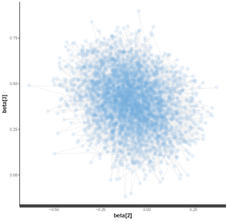

## Simulating choice shares in R using posterior draws

## Function for computing shares from a point estimate of beta

```r
shares.mnl.point <- function(beta,  # vector of parameters (part-worths)
                             X) {   # attribute matrix X for scenario (coded)
  if (length(beta) != ncol(X))
    stop("length of beta doesn't match columns in X")
  V <- exp(X %*% beta)
  data.frame(shares=V/sum(V), X)
}
```

## Computing shares from point estimates (1)

Pull out the posterior means of beta.

```r
beta.mean <- summary(choc.stan)$summary[1:9,1]
beta.mean
```

```
##     beta[1]     beta[2]     beta[3]     beta[4]     beta[5]     beta[6]
## -0.31433151 -0.08335508  0.40454140  0.45937060 -0.54291065  0.49525385
##     beta[7]     beta[8]     beta[9]
##  0.17415063  0.58916820 -0.01226111
```

## Computing shares from point estimates (2)

Compute shares. **This is bad practice as it does not account for our uncertainty in beta!**

```r
shares.mnl.point(beta.mean, choc.standata$X[[1]])
```

```
##       shares Price BrandDove BrandGhirardelli BrandGodiva BrandHersheys
## 1 0.38758042   0.6         1                0           0             0
## 2 0.58833796   0.7         0                0           1             0
## 3 0.02408162   3.6         1                0           0             0
##   TypeDark TypeDarkNuts TypeMilk TypeMilkNuts
## 1        0            0        1            0
## 2        1            0        0            0
## 3       -1           -1       -1           -1
```

## Posterior draws of `beta`

To understand the full posterior of the shares, we should use all of the posterior draws for beta, which represent out uncertainty in `beta`.

```r
beta.draws <- extract(choc.stan, pars="beta")$beta
head(beta.draws)
```

```
##
## iterations       [,1]         [,2]      [,3]      [,4]       [,5]
##       [1,] -0.3478703  0.080482142 0.1982551 0.3997360 -0.4916839
##       [2,] -0.3848950 -0.277779343 0.4747460 0.3318566 -0.3193495
##       [3,] -0.2097009 -0.233821846 0.4922533 0.4403002 -0.5418049
##       [4,] -0.2575421 -0.104066720 0.3681182 0.4721159 -0.7740544
##       [5,] -0.3611979 -0.007947251 0.5943515 0.4500375 -0.8675597
##       [6,] -0.3023791 -0.017249531 0.2073573 0.4758840 -0.7463994
##
## iterations      [,6]       [,7]      [,8]        [,9]
##       [1,] 0.4956138 0.17113025 0.5858199  0.03014834
##       [2,] 0.3976540 0.25159835 0.8122452 -0.27290201
##       [3,] 0.5960043 0.07043425 0.3797149  0.17093460
##       [4,] 0.6792963 0.41529620 0.6517011 -0.22398854
##       [5,] 0.3745087 0.05316832 0.5126430  0.08792478
##       [6,] 0.4500410 0.28622403 0.4238720 -0.12191060
```

## Function for computing shares for each of the posterior draws of `beta`

Once you have a set of posterior draws for the model parameters, you can obtain posterior draws for any function of those parameters by computing the function for each draw.

```r
shares.mnl.post <- function(draws,  # matrix of draws (use extract())
                            X) {    # attribute matrix X for scenario
  shares <- matrix(NA, nrow=nrow(draws), ncol=nrow(X))
  for (draw in 1:nrow(draws)) {
     shares[draw,] <- shares.mnl.point(draws[draw,], X)[,1]
  }
  shares
}
```

## Posterior distribution of shares (1)

```r
shares.draw <- shares.mnl.post(beta.draws, choc.standata$X[[1]])
summary(shares.draw)
```

```
##        V1               V2               V3
##  Min.   :0.1903   Min.   :0.3502   Min.   :0.006366
##  1st Qu.:0.3426   1st Qu.:0.5399   1st Qu.:0.018668
##  Median :0.3869   Median :0.5870   Median :0.023983
##  Mean   :0.3889   Mean   :0.5858   Mean   :0.025323
##  3rd Qu.:0.4319   3rd Qu.:0.6336   3rd Qu.:0.030514
##  Max.   :0.6292   Max.   :0.7961   Max.   :0.068483
```

## Posterior distribution of shares (2)

```r
apply(shares.draw, 2, quantile, probs=c(0.5, 0.025, 0.975))
```

```
##            [,1]      [,2]       [,3]
## 50%   0.3868640 0.5870258 0.02398315
## 2.5%  0.2640505 0.4449724 0.01161982
## 97.5% 0.5260401 0.7156864 0.04596499
```

## Summary of Module 2

## In this module we have

- Built a multinomial logit model in Stan.
  - `data`, `parameters` and `model` blocks
  - core data types: arrays, vectors, matrices
  - sampling statements and distributions
- Tested the model using synthetic data.
- Estimated the model using chocolate bar CBC data.
- Computed the full posterior of shares based on the posterior draws of `beta`.
- Learned about the `Rhat` and `n_eff` measures for assessing convergence.

Next, we move on to hierarchical models.